# Final Report

due November 16, 2021 by 11:59 PM

Isabel Siebrecht, Franklin Feng, & Kaylin Hernandez

11/16/21

## Introduction

In this project, we chose to research what factors in our world influences the rate of teenage pregnancies. We consider premature pregnancies to be a very significant indicator of a country’s development and prosperity. Considering the repercussions of lost economic contributions and dependency on costly public programs [https://www.ncbi.nlm.nih.gov/books/NBK219229/], we hope our findings can spur a decrease in the rate of teenage pregnancies by encouraging governments to focus on the strongest predictor variables linked to adolescent births.

In essence, we attempt to answer how a country’s quality of life, measured by human and economic resources, correlates to the birth rates for teenagers aged 15 to 19 years old. To answer our question, our explanatory variables of adolescent pregnancy rates are female educational attainment, GDP annual growth rate, life expectancy at birth, HDI, labor force participation rate, and gender inequality index.

Information provided by Youth.gov supports our predictors because they broadly encompass the individual, family, and community that influence teenage pregnancies ([Youth.gov](https://youth.gov/youth-topics/pregnancy-prevention/risk-and-protective-factors)).

As a note, we acknowledge that our findings are based on preconceived, Western assumptions of what qualifies as a global indicator of “status.” Thus, we conducted this report on our assumptions of what defines a country’s prosperity and development.

## Methodology

There were a few sources that our data was obtained. We mainly worked with the 2020 Human Development Report, courtesy of the United Nationas Development Programme. With a vast array of variables available to analyze, we selected female educational attainment (number of years of schooling), GDP and related economic indicators, adolescent birth rate, life expectancy at birth, maternal mortality rate, HDI index, labor force participation rate, and the gender inequality index. We also obtained additional data on adolescent birth rates from the World Health Organization who collected the results via various national and international surveys and country reports, though this dataframe was largely utilized for reference purposes.

The logic of constructing our project was to try and explore different relationships between these variables and try to create combinations that lead back to their effect(s) on adolescent birth rates. There are many different ways of exploring this data and to create the clearest, most straightforward analysis we created various plots and analyses. Ultimately, we seek to maximize our explanatory power in the relationship between a country’s resources and adolescent birth rates and identifying those specific variables that really move the needle.

## Intro to data

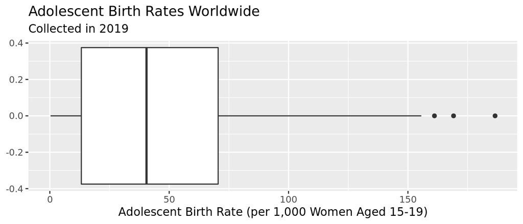

```
##    0%   25%   50%   75%  100%
##   0.3  13.2  40.5  70.5 186.5
```

## Relationships

After looking at the distribution of birth rate data, we decided to explore if there was a relationship between our chosen factors and adolescent pregnancy rates. Therefore, we plotted our seven explanatory variables (maternal mortality rate, female educational attainment, GDP, life expectancy at birth, 2019 HDI index, and gender development index) onto separate scatter plots. The relationships will then be modeled with a linear regression to determine the significance of adolescent birth rates an independent indicator has.

**Is Maternal Mortality Ratio Related to Adolescent Birth Rate?**

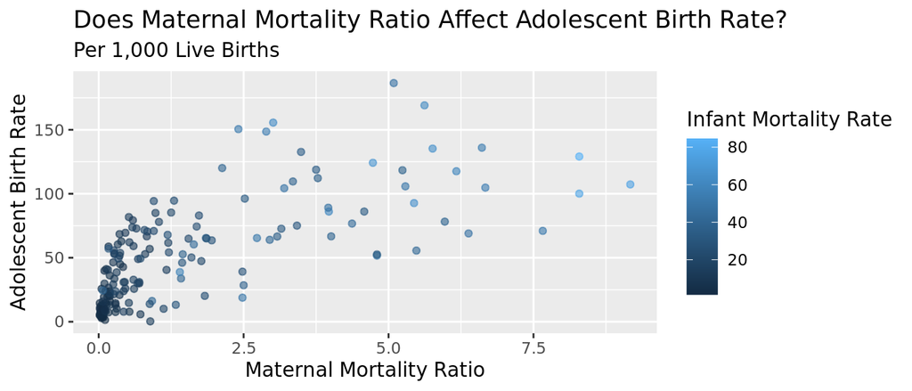

```
## [1] 0.7175514
```

**Is Female Educational Attainment Related to Adolescent Birth Rate?**

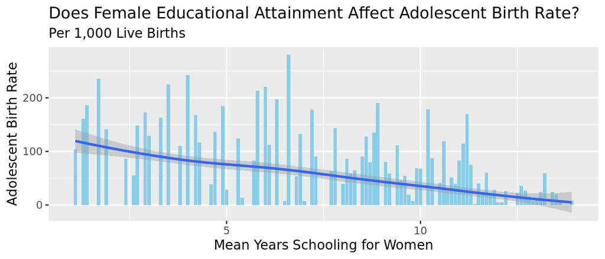

```
## [1] -0.7041979
```

**Is GDP Annual growth rate related to adolescent birth rate?**

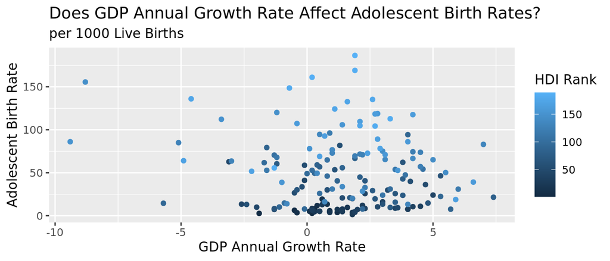

```
## [1] -0.1668382
```

| term | estimate | std.error | statistic | p.value |
| --- | --- | --- | --- | --- |
| (Intercept) | 78.7482140916 | 5.6598385691 | 13.91350886 | 1.864597e-29 |
| GDP_num | -0.0007546602 | 0.0009566465 | -0.78886001 | 4.313468e-01 |
| GDP_Annual_Growth | -2.8447733029 | 0.9274207179 | -3.06740323 | 2.531323e-03 |
| GDP_per_Capita | 0.0008008501 | 0.0006511359 | 1.22992764 | 2.205073e-01 |
| Consumer_Price_Index | -0.0000705832 | 0.0229260796 | -0.00307873 | 9.975473e-01 |
| GNI_Per_Capita | -0.0021304178 | 0.0006943137 | -3.06837906 | 2.523528e-03 |

We next asked ourselves if strictly economic indicators can be telling in differences in adolescent birth rate. The results were much more muddy than anticipated. For example, we plotted Gross Domestic Product (GDP) annual growth rate, which signifies the yearly average rate of change of GDP at market prices based on constant local currency, for a given national economy, during a specified time ([The Balance](https://www.thebalance.com/u-s-gdp-growth-3306008)). The plot shows an unclear relationship between GDP annual growth rate and adolescent birth rate. It is to be noted, however, that the HDI index has a substantial impact on the rate of adolescent births as clearly shown on the plot delineated by color.

**Is life expectancy at birth related to adolescent birth rate?**

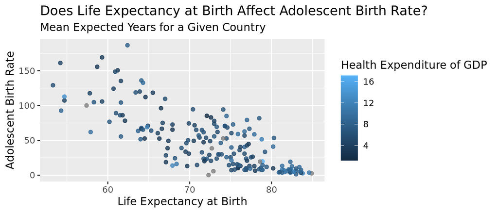

```
## [1] -0.7784798
```

This graph shows a strong, negative, linear relationship (r = -0.778) between life expectancy at birth and adolescent birth rate, meaning as life expectancy increases, adolescent birth rate decreases. This makes logical sense because women would have less need to reproduce if their children are expected to have a long lifespan. In addition, we applied an overlay of Health Expenditure of GDP to study if this variable affects both life expectancy and adolescent birth rates. As seen, there is not an extremely clear pattern exhibited, but in general the trend tends to be that those countries with a higher devotion of Health Expenditure relative to their GDP came out to longer life expectancies and lower adolescent birth rates.

**Is HDI in 2019 related to adolescent birth rate?**

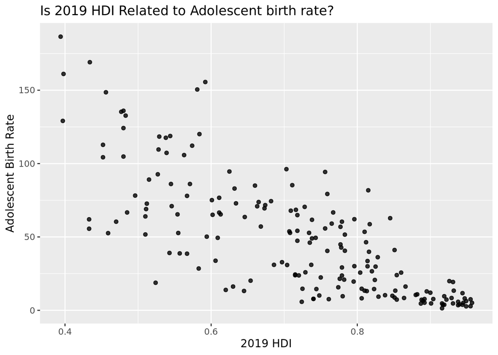

```
## [1] -0.7741174
```

HDI, also known as the Human Development Index, is a statistic used to rank countries. There is clearly a relatively strong negative linear relationship (r = -0.774) between 2019 HDI and adolescent birth rate (per 1,000 women aged 15-19 years old), meaning as the HDI increases, the rate of adolescent birth rates decrease. This relationship makes sense because unlike that of other economic indicators like GDP and GNI above, HDI is a more holistic indicator of a country’s resources, its condition both economically and health-wise, and the level of democracy that exists. The confluence of these factors helps to build the HDI index and therefore it commands a far better relationship with adolescent birth rates than many other single standing variables.

**Is labor force participation rate related to adolescent birth rate?**

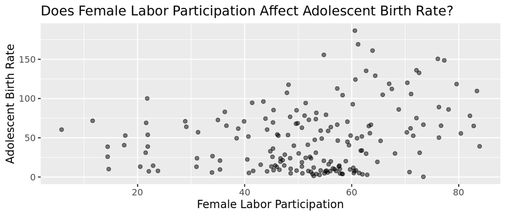

```
## [1] 0.2551033
```

**Is the gender develop index related to adolescent birth rate?**

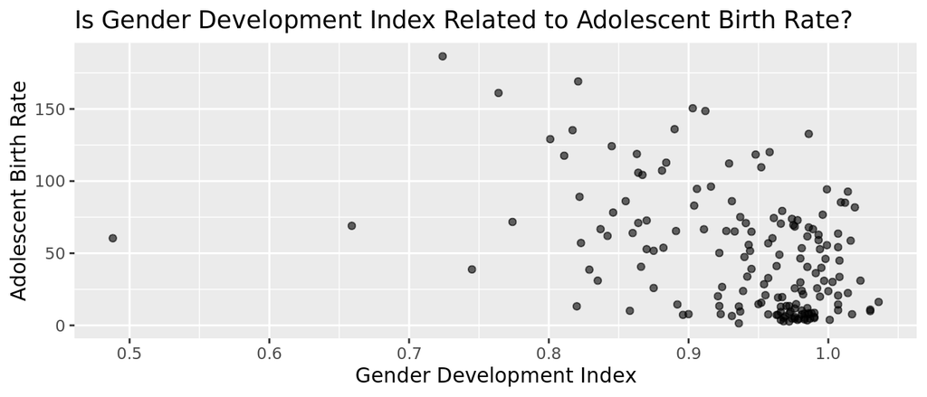

```
## [1] -0.4247212
```

# Linear regression

After looking to see possible relationships, we decided to run a linear regression analysis in order to determine which predictors had the most influence over teenage pregnancy rates and what that relationship is. The general null hypothesis test for every explanatory variable is $\beta\ = 0$, which indicates that there is no difference in influence when we control for each one individually.

**Which variable has the most significant correlation to adolescent birth rate?**

| term | estimate | std.error | statistic | p.value | conf.low | conf.high |
| --- | --- | --- | --- | --- | --- | --- |
| (Intercept) | 14.978683827 | 55.701520857 | 0.2689098 | 7.884389e-01 | -9.525299e+01 | 125.21035609 |
| GDP | 0.008397017 | 0.008513583 | 0.9863082 | 3.258721e-01 | -8.451113e-03 | 0.02524515 |
| Maternal_Mortality_Ratio | 0.019284674 | 0.016102912 | 1.1975893 | 2.333250e-01 | -1.258251e-02 | 0.05115186 |
| Mean_Years_Schooling_Female | 2.036216329 | 1.540077202 | 1.3221521 | 1.885127e-01 | -1.011551e+00 | 5.08398384 |
| Life_Expectancy_Birth | -0.129738011 | 0.775439410 | -0.1673090 | 8.673951e-01 | -1.664310e+00 | 1.40483379 |
| HDI_2019 | -79.696944658 | 58.770156140 | -1.3560785 | 1.774994e-01 | -1.960014e+02 | 36.60746662 |
| Labour_Participation_Female | 0.606903415 | 0.138316757 | 4.3877794 | 2.395052e-05 | 3.331786e-01 | 0.88062821 |
| Gender_Inequality_Index | 134.916611890 | 26.072171618 | 5.1747363 | 8.746569e-07 | 8.332055e+01 | 186.51267305 |

## Interpretation

Out of the seven variables we fitted in the linear regression, we see that only two explanatory variables (female labor participation and gender inequality index) have p-values smaller than our alpha 0.05 (2.395e<sup>-05</sup> and 8.747e<sup>-07</sup>, respectively). Thus, these two variables reject our null hypothesis that there is no difference in influence over all of the explanatory predictors.

Furthermore, considering comparatively higher correlation between gender inequality index and adolescent birth rate, we decided to further analyze this variable in a more detailed scatter plot below.

# Looking further at Gender Inequality Index

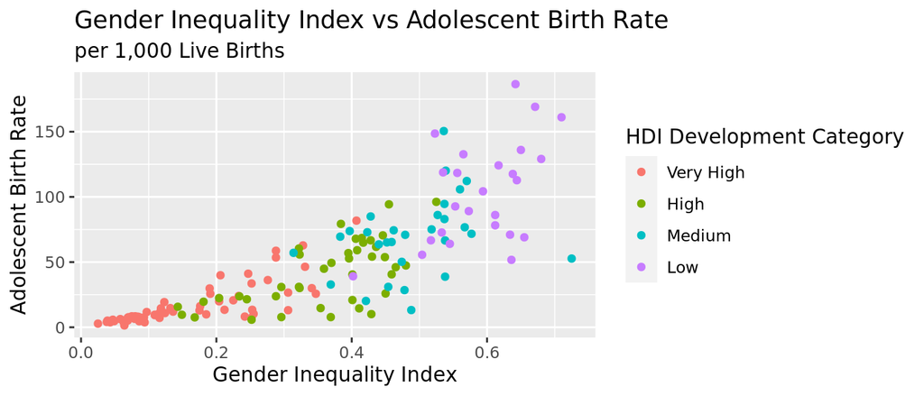

The gender equality index measures the gender disparity in a country on a scale from 0 to 1. The greater the value, the greater the measure of inequality.

HDI reflects economic prosperity in a country, so we broke the HDI rankings up into four categories to visualize the hypothesis that wealth plays a major roll in access to equality. Since gender inequality is such a broad issue we wanted to look at wealth desperation in conjunction. This plot supports the idea that wealthier countries tend to have lower gender equality disparities and lower rates of teen births, and vice versa. Our plot, organized by HDI rank, can help us select which countries will benefit most from our intervention targeting wealth and gender inequality to improve adolescent birth rates.

# Summary & Next Steps

In summation, although we recognize that correlation does not mean causation, we recommend that the intervention created to reduce the number of adolescent births focus on the communities with the highest rates, countries with low HDI rank, and do so by addressing the gender inequality in these countries. Sine we have a finite amount of resources, it is best to put them towards low HDI countries. Since our highest correlating variable was gender inequality, the most efficient way to help adolescent birth rates decrease will be to try and close this gap. Some ways that can help close the gender equality gap are encouraging girls to stay in school and pursue and education. If girls acquire skills that make not just their bodies, but their minds valuable to society then they will be encouraged to pursue careers and higher degrees, thus waiting to have children until they are older. Women who give birth later in life don’t only have less pregnancy related health risks than teen mothers, but they are also more economically stable, and therefore able to give their children a better quality of life.